# Homework #5

#### Computing ID: cx2rx

**SYS 6018 | Fall 2020 | University of Virginia**

### Problem 5.1 Geographic Profiling

Geographic profiling, a method developed in criminology, can be used to estimate the [home location (roost) of animals](https://www.sciencedirect.com/science/article/pii/S0022519305004157) based on a collection of sightings. The approach requires an estimate of the distribution the animal will travel from their roost to forage for food.

A sample of $283$ distances that pipistrelle bats traveled (in meters) from their roost can be found at: https://mdporter.github.io/SYS6018/data/geo_profile.csv

One probability model for the distance these bats will travel is:
$$\begin{align*}
f(x; \theta) = \frac{x}{\theta} \exp \left( - \frac{x^2}{2 \theta} \right)
\end{align*}$$
where the parameter $\theta > 0$ controls how far they are willing to travel.

1. Derive the MLE for $\theta$ (i.e., show the math).

Given the probability model function, we can first derive the Log-Likelihood function
$$\begin{aligned}
log L(\theta) & = \sum_{i = 1}^{n} log f(x_i; \theta) \\
& = \sum_{i = 1}^{n} log \left[ \frac{x_i}{\theta} \exp \left( - \frac{x_i^2}{2 \theta} \right)\right]\\
& = \sum_{i = 1}^{n} log (\frac{x_i}{\theta}) - \frac{x_i^2}{2 \theta} \\
& = \sum_{i = 1}^{n} log(x_i) - log(\theta) - \frac{1}{2}x_i^2 \times \theta^{-1} \\
\end{aligned}$$

In order to find the $\theta$ that maximize the likelihood function, we are going to take a partial derivative of $\theta$ and set that equation to be zero.

$$\frac{d log(L)}{d\theta} = - \frac{n}{\theta} + \sum_{i = 1}^{n} \frac{1}{2}x_i^2 \frac{1}{\theta^2} = 0$$
Therefore, we can get:
$$\sum_{i = 1}^{n} \frac{1}{2}x_i^2 \frac{1}{\theta^2} = \frac{n}{\theta}$$
Since $\theta > 0$, we let both sides of the equation times $\theta^2$
$$\sum_{i = 1}^{n} \frac{1}{2}x_i^2 = n\theta \Rightarrow \theta = \frac{1}{n} \sum_{i = 1}^{n} \frac{1}{2}x_i^2$$

2. What is the MLE of $\theta$ for the bat data? (Use results from a, or use computational methods.)

```r
# Read in the data
data <- read_csv("https://mdporter.github.io/SYS6018/data/geo_profile.csv", col_names = F)

# Calculate theta
theta <- mean(0.5 * (data$X1)^2)
print(theta)
```

```
#> [1] 4.524186
```

3. Using the MLE value of $\theta$ from part b, compute the estimated density of this distribution at a set of evaluation points between 0 and 8 meters. Plot the estimated density.

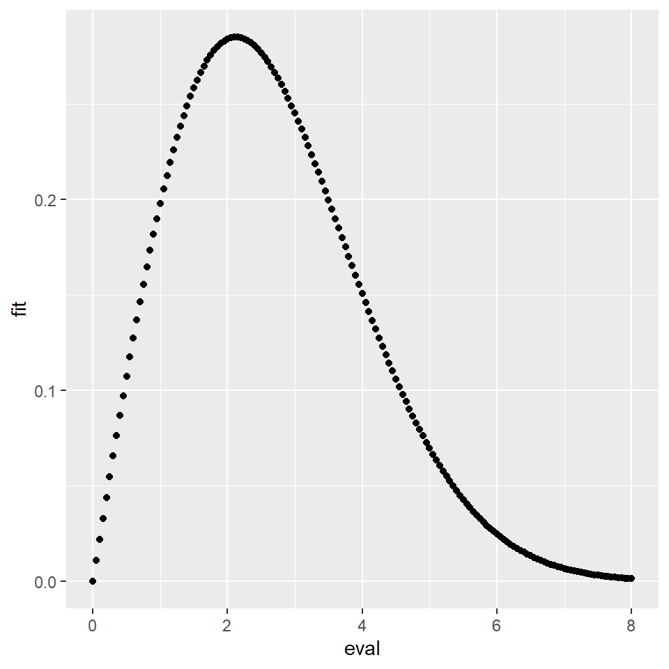

```r
# Create a data frame to store the values
estimated_density <- data.frame(eval = seq(0, 8, 0.05)) %>%
  mutate(fit =  eval / theta * exp(- eval^2 / (2* theta)))
# Create the density plot
ggplot() +
  geom_point(data = estimated_density, aes(x = eval, y = fit))
```

4. Estimate the density using KDE. Report the bandwidth you chose and produce a plot of the estimated density.

```r
# Running the KDE model
model_kde <- kde(data$X1)

# Report the bandwidth - h
model_kde$h
```

```
#> [1] 0.3910206
```

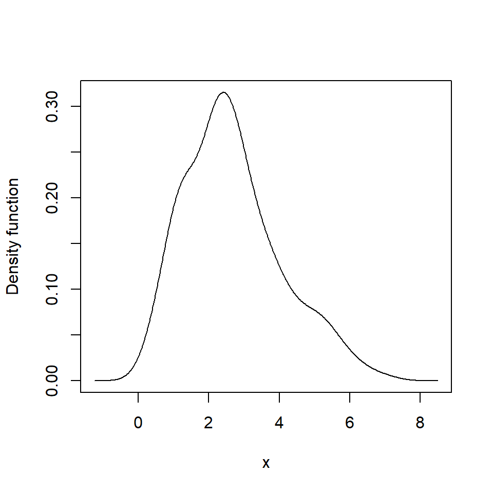

```r
# Create a plot of the estimated density
plot(model_kde)
```

5. Which model do you prefer, the parametric or KDE?

I prefer KDE. Clearly, parametric approach gives us the exact density shape once we find the optimal $\theta$. However, without doing any calculus, we can find an reasonably good density estimation using KDE very quickly.

### Problem 5.2: Interstate Crash Density

Interstate 64 (I-64) is a major east-west road that passes just south of Charlottesville. Where and when are the most dangerous places/times to be on I-64? The crash data (link below) gives the mile marker and fractional time-of-week for crashes that occurred on I-64 between mile marker 87 and 136 in 2016. The time-of-week data takes a numeric value of *<dow>.<hour/24>*, where the dow starts at 0 for Sunday (6 for Sat) and the decimal gives the time of day information. Thus `time=0.0417` corresponds to Sun at 1am and `time=6.5` corresponds to Sat at noon).

- **Crash Data**: https://mdporter.github.io/SYS6018/data/crashes16.csv
1. Extract the crashes and make a scatter plot with mile marker on x-axis and time on y-axis.

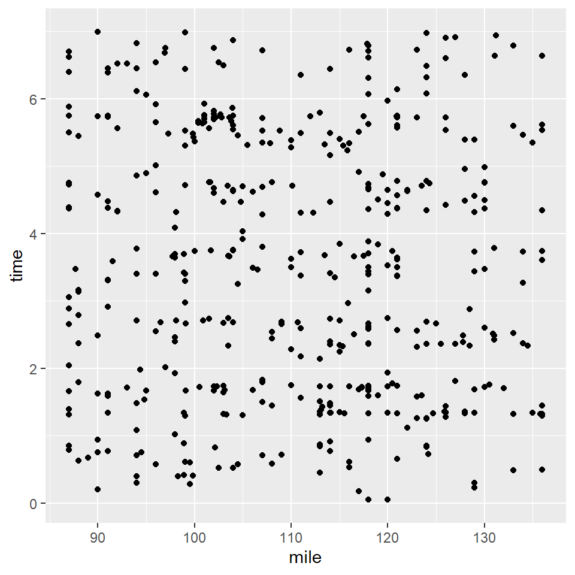

```r
# Read in the data
data <- read_csv("https://mdporter.github.io/SYS6018/data/crashes16.csv")
# Create the scatter plot
ggplot() + geom_point(data = data, aes(x = mile, y = time))
```

2. Use KDE to estimate the *mile marker* density. Report the bandwidth and plot the density estimate.

```r
# Running the KDE model
model_kde <- kde(data$mile)

# Report the bandwidth - h
model_kde$h
```

```
#> [1] 2.894092
```

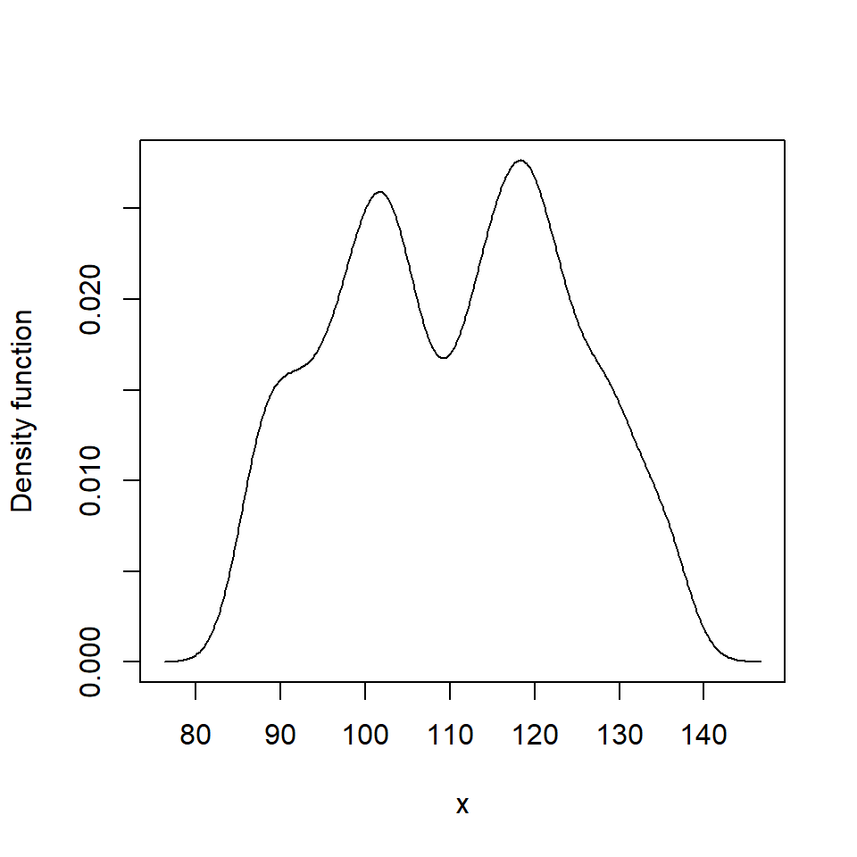

```r
# Create a plot of the estimated density
plot(model_kde)
```

3. Use KDE to estimate the temporal *time-of-week* density. Report the bandwidth and plot the density estimate.

```r
# Running the KDE model
model_kde <- kde(data$time)

# Report the bandwidth - h
model_kde$h
```

```
#> [1] 0.414127
```

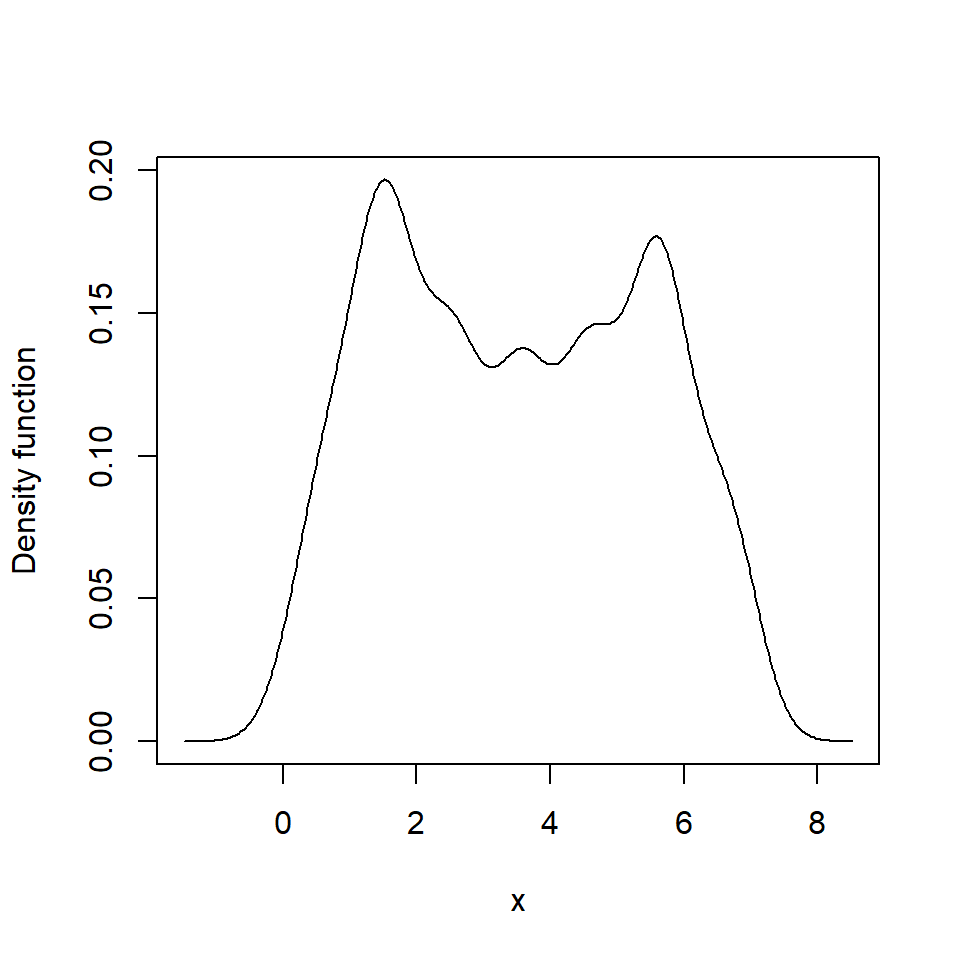

```r
# Create a plot of the estimated density
plot(model_kde)
```

4. Use KDE to estimate the bivariate mile-time density. What are the bandwidth parameters? Plot the bivariate density estimate.

```r
# Smoothed cross-validation bw estimator
H = Hscv(data)

# Running the KDE model
model_kde <- kde(data, H = H)

# Report the bandwidth parameters - H
model_kde$H
```

```
#>            [,1]       [,2]
#> [1,] 25.9921201 -0.1523207
#> [2,] -0.1523207  0.3660496
```

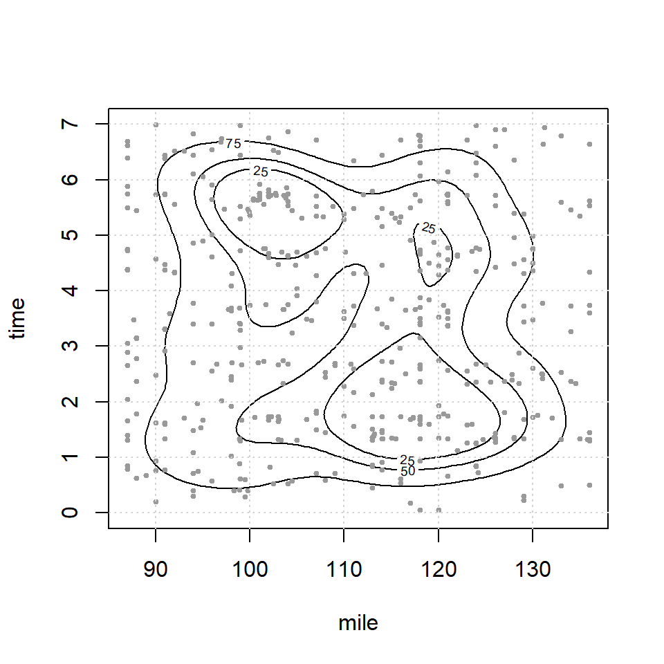

```r
# Create a plot of the estimated density
plot(model_kde, xlim = c(87, 136), ylim = c(0, 7))
points(data, pch = 19, cex = .5, col = 'grey60')
grid()
```

5. Based on the estimated density, approximate the most dangerous mile marker and time-of-week.

Approach 1: Using the Contour Plot and abline:

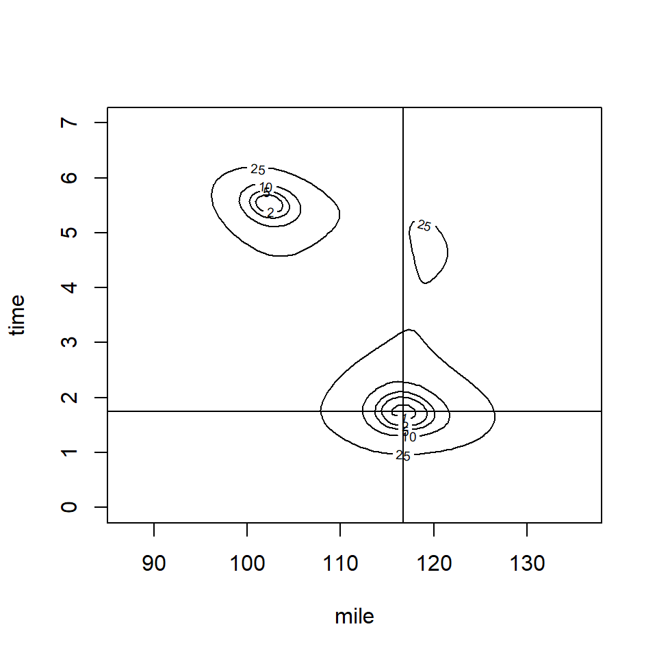

```r
# Re draw the contour plot with 1%, 2%, 5%, 10% and 25% confidence interval
plot(model_kde, cont = c(1, 2, 5, 10, 25), xlim = c(87, 136), ylim = c(0, 7))
abline(h = 1.75, v = 116.7, untf = FALSE)
```

Based on the contour plot with 1% confidence interval and the abline on the contour plot, I am able to locate the most dangerous mile marker and time-of-week and they are **mile marker 116.7 and time-of-week 1.75 (Monday, 6 PM)**.

Approach 2: Another approach for this is to find the maximum estimated density for the particular mile marker and time-of-week:

```r
est <- model_kde$estimate
index <- which(est == max(est), arr.ind = TRUE)

# The most dangerous mile marker is
model_kde$eval.points[[1]][index[1]]
```

```
#> [1] 116.7036
```

```r
# The most dangerous time-of-week is
model_kde$eval.points[[2]][index[2]]
```

```
#> [1] 1.768988
```

Using this approach, I am able to locate the most dangerous mile marker and time-of-week and they are **mile marker 116.7036 and time-of-week 1.768988 (Monday, 6:27 PM)**.